# Improved Slides

9/20/2019

## Class assignment:

Using the MPG dataset, which is available with the ggplot2 library, produce a document that includes the following elements: headers, text, tables, and plots.

Tables should include a comparison of city and highway mileage by the class of car and the best three car models for city and highway mileage for all the years in which data is available.

Plot the data displaying as much of the data as you can. Put continuous variables on the axes and include a locally smoothed regression line to show the relationship with mileage. Also make a box plot comparing city and highway MPG by class of car.

## Table 1

This example is flawed even though the code works. Explain. And now that you know how to produce the table can you improve the code by using an **apply** functional?

Explain: This example is flawed because it uses a for loop, which runs very slow in R. It can be improved by using a tapply functional.

|  | cty_mean | hwy_mean |
| --- | --- | --- |
| 2seater | 15.40 | 24.80 |
| compact | 20.13 | 28.30 |
| midsize | 18.76 | 27.29 |
| minivan | 15.82 | 22.36 |
| pickup | 13.00 | 16.88 |
| subcompact | 20.37 | 28.14 |
| suv | 13.50 | 18.13 |

## Table 2

The next table is a bit tricky.

|  | Milage |  | Milage |  | Milage |  | Milage |
| --- | --- | --- | --- | --- | --- | --- | --- |
| new beetle | 26 | new beetle | 35 | corolla | 27 | corolla | 36 |
| civic | 24.8 | corolla | 32.67 | civic | 24 | civic | 33.75 |
| corolla | 24.67 | civic | 31.6 | gti | 21.5 | camry | 30 |

## ggplot 1

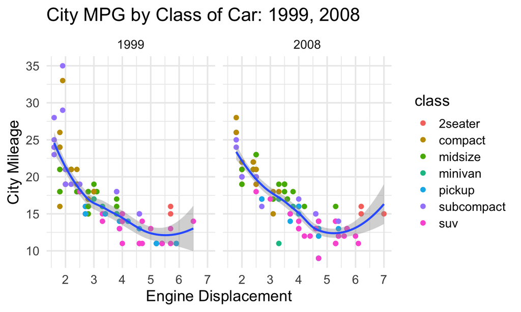

## ggplot 1

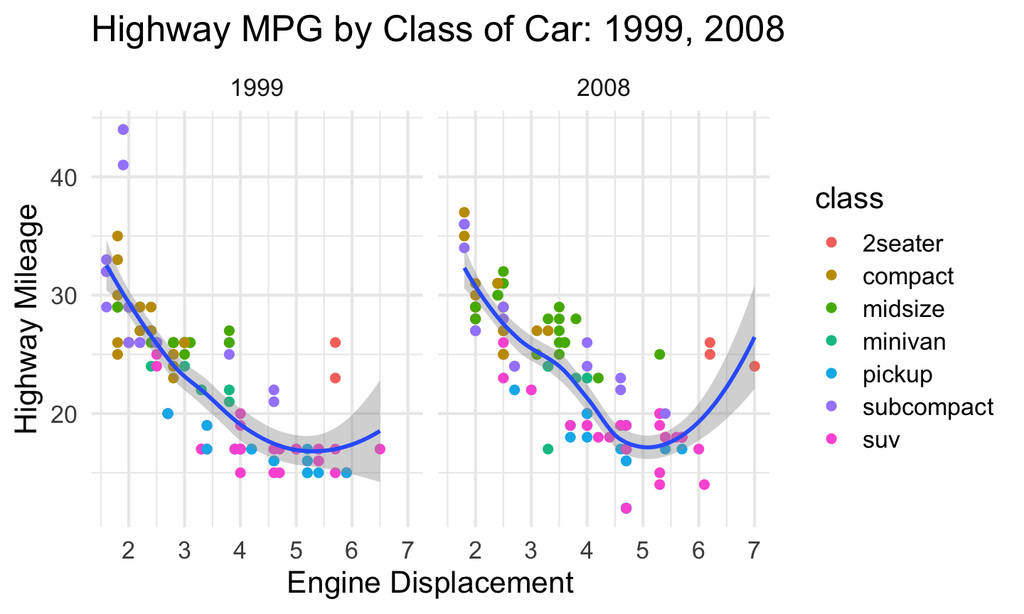

## Boxplot 1

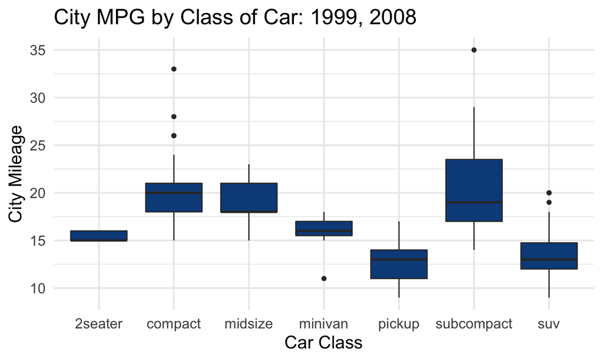

## Boxplot 1

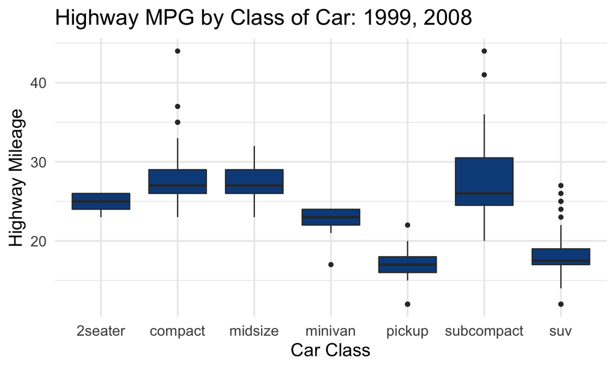